# Mucin Supplementation Analysis Report

G. Brett Moreau

January 31, 2021

### Summary of Results

- There were no differences in richness between samples, but evenness was increased in 4 week samples (both Stress Alone and Stress + Mucin) compared to earlier samples.
- Differences in beta diversity were observed between all groups, particularly between samples collected at four weeks and samples collected at earlier timepoints.
- Phylum- and Family-level community composition changes were observed across groups. Several Families (including *Lactobacillaceae* and *Muribaculaceae*) were changed between Baseline and 3 week stress conditions, while a couple (*Rikenellaceae* and *Marinifilaceae*) were changed between Stress Alone and Stress + Mucin conditions.
- Random Forest models successfully distinguish between both Baseline and 3 Week Stress groups and Stress Alone and Stress + Mucin Groups.

### Introduction

The purpose of this experiment is to investigate the microbiome of stressed mice whose diet has or has not been supplemented with mucin. Behavioral experiments have observed some changes in stress behavior after mucin supplementation. Previous experiments have also identified changes in the microbiota, particularly *Lactobacillus* spp., that are associated with changes in stress response. Because of this, we hypothesize that mucin supplementation influences the intestinal microbiota to drive behavioral changes.

### Characterization of the Data Set

There are 71 samples in this experiment. Samples were divided into two groups (Control and Mucin-supplemented) and three different timepoints (pre-stress, 3 weeks post-stress, and 4 weeks post-stress). Four week samples are broken into two groups: Stress Alone, which is the control group, and Stress + Mucin, which is has a diet supplemented with 5% mucin. There are 24 mice at Baseline and 3 Weeks Stress, 12 mice for Stress Alone, and 11 mice for Stress + Mucin (Sample #167 was removed due to low read counts), giving our 71 samples.

Below is a general overview of the total number of reads in the data set, the mean and median number of reads/sample, and the range of reads across this data set.

```r
sum(total.reads)
```

```
## [1] 4784563
```

```r
mean(total.reads)
```

```
## [1] 67388.21
```

```r
median(total.reads)
```

```
## [1] 66966
```

```r
range(total.reads)
```

```
## [1]  39993 101514
```

### Alpha Diversity

I’ll first investigate alpha diversity, which examines diversity within a given sample. Alpha diversity consists of two major measures:

- **Richness**: the number of taxonomic groups within a given sample.
- **Evenness**: how evenly abundances of taxonomic groups are distributed in a given sample.

The DADA2 pipeline removes singlets (sequences detected only once) from the data set, as it does not have enough confidence to determine whether these sequences are real or artifacts. Because of this, measures of richness fail explicitly and are difficult to interpret. I’ll focus mainly on measures of evenness but give measures of richness a glance to see if there are any major differences.

#### Richness

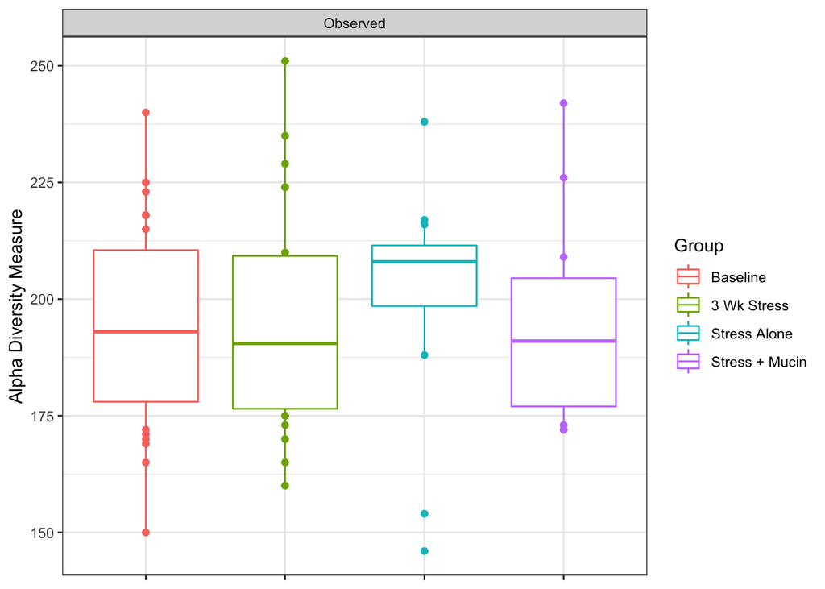

```
##
##  Pairwise comparisons using Wilcoxon rank sum test with continuity correction
##
## data:  richness$Observed and sample_data(ps.mucin)$Group
##
##                Baseline 3 Wk Stress Stress Alone
## 3 Wk Stress    1        -           -
## Stress Alone   1        1           -
## Stress + Mucin 1        1           1
##
## P value adjustment method: bonferroni
```

There are no major differences in alpha diversity between groups.

#### Evenness

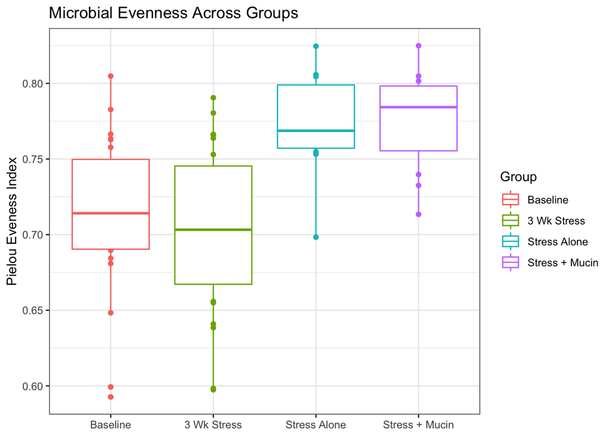

```
## List of 1
##  $ legend.position: chr "none"
##  - attr(*, "class")= chr [1:2] "theme" "gg"
##  - attr(*, "complete")= logi FALSE
##  - attr(*, "validate")= logi TRUE
```

Baseline and 3 Week Stress samples look similar to each other, while 4 week samples (Stress Alone and Stress + Mucin) appear to have higher evenness . A Pairwise Wilcoxon Rank Sum Test with Bonferroni correction from multiple comparisons was performed to test for differences between groups.

```
##
##  Pairwise comparisons using Wilcoxon rank sum exact test
##
## data:  evenness$pielou and sample_data(ps.mucin)$Group
##
##                Baseline 3 Wk Stress Stress Alone
## 3 Wk Stress    1.0000   -           -
## Stress Alone   0.0023   0.0005      -
## Stress + Mucin 0.0023   0.0011      1.0000
##
## P value adjustment method: bonferroni
```

There was no significant difference in evenness between Baseline and 3 Week Stress samples. However, both 4 week samples (Stress Alone and Stress + Mucin) were significantly higher than either Baseline or 3 Week Stress groups. No significant difference in evenness was observed between Stress Alone and Stress + Mucin groups.

### Beta Diversity

I’ll now investigate differences in beta diversity, or diversity between different samples in the experiment. I’ll use Bray-Curtis Dissimilarity as my measure for beta diversity in this study, and I’ll use Non-metric Multidimensional Scaling (NMDS) to visualize dissimilarity distances between samples.

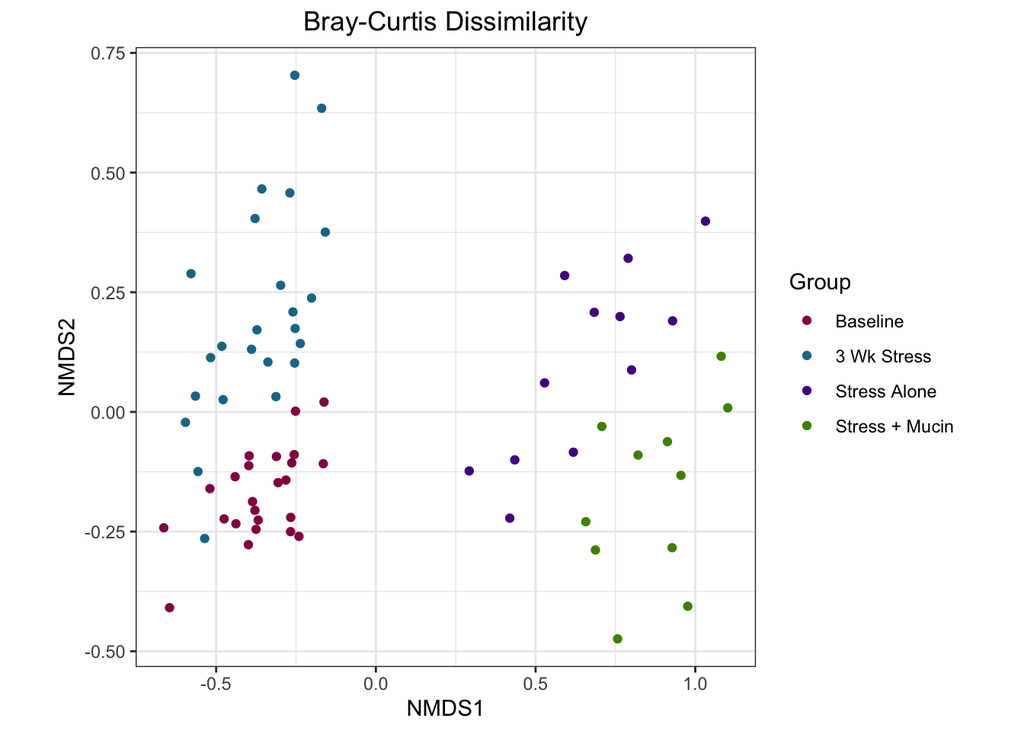

Looking at the clustering, it appears that groups cluster distinctly from each other. Baseline and 3 Week Stress groups are relatively similar to each other, and 4 week samples (Stress Alone and Stress + Mucin) are relatively similar to each other. Baseline and 3 Week samples are quite distinct from 4 week samples.

I’ll now use ADONIS to calculate statistical differences between groups.

| combinations | permanova.p.bray | permanova.FDR.bray |
| --- | --- | --- |
| Baseline/3 Wk Stress | 0.001 | 0.006 |
| Baseline/Stress Alone | 0.001 | 0.006 |
| Baseline/Stress + Mucin | 0.001 | 0.006 |
| 3 Wk Stress/Stress Alone | 0.001 | 0.006 |
| 3 Wk Stress/Stress + Mucin | 0.001 | 0.006 |
| Stress Alone/Stress + Mucin | 0.001 | 0.006 |

The PERMANOVA data confirms the initial impressions from the NMDS plot: All groups cluster separately from each other and are statistically significant from every other group.

### Changes in Community Composition

There appear to be some broad differences in diversity between groups. I’ll now see if this is reflected by any broad changes in community composition across groups. I’ll start by looking at the phylum level, then move on to differences at the Family level. This analysis will focus on taxa that make up at least 1% of the relative abundance in at least one group.

#### Phylum-level Community Composition

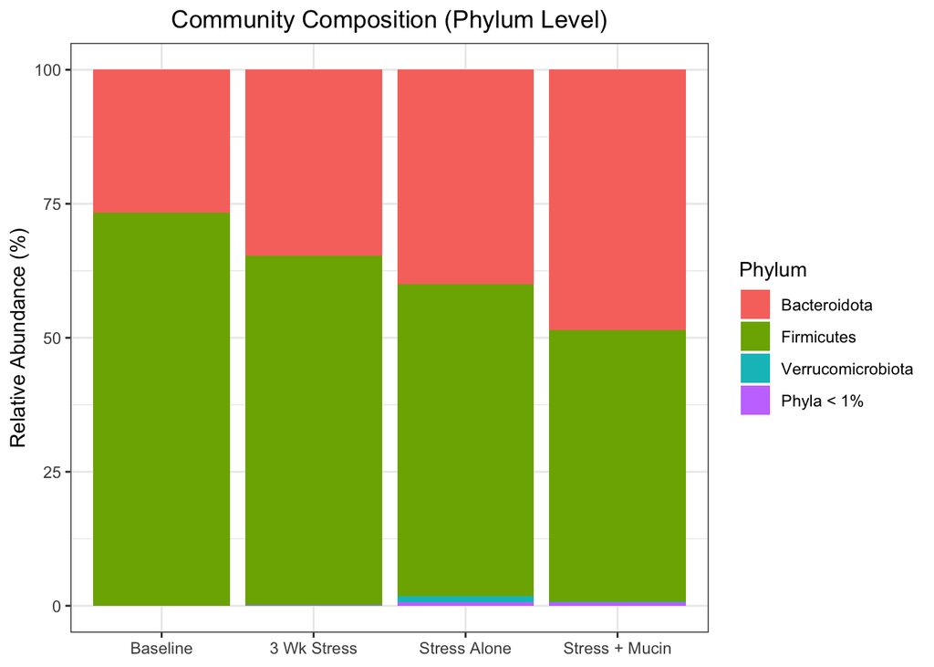

At the Phylum level, samples are dominated by members of the *Bacteroidota* and *Firmicutes* phyla. There is a general trend of relative decreased abundance in *Firmicutes* and relative increased abundance of *Bacteroidota* over the course of the experiment.

#### Family-Level Community Composition

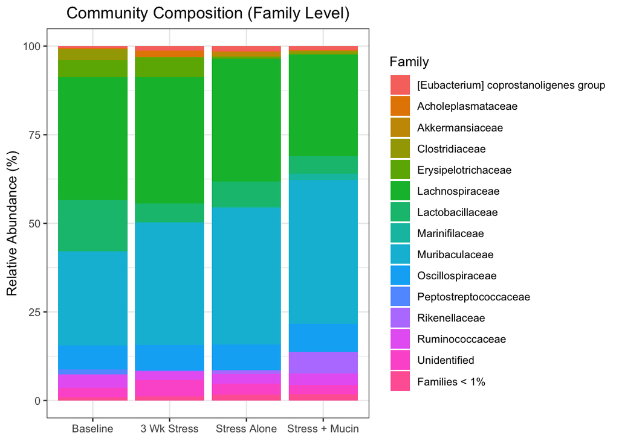

Several Families are abundant across all groups, with the most abundant families including *Lachnospiraceae* and *Muribaculaceae*. I’ll directly compare relative abundances of these families between groups of interest (Baseline vs.3 Week Stress and Stress Alone vs. Stress + Mucin).

#### Baseline vs. 3 Week Stress

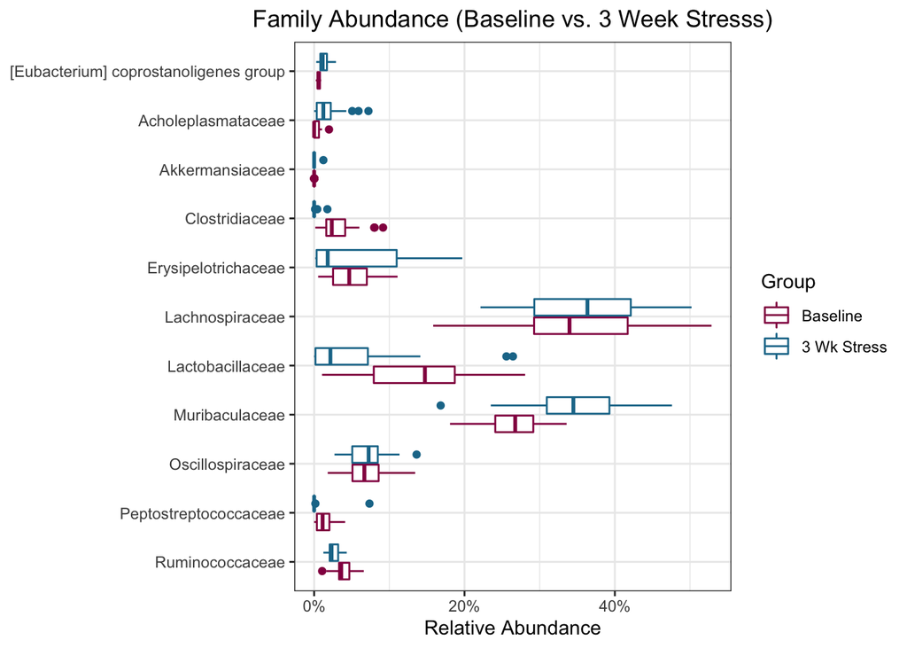

| Family | Raw p value | Bonferroni-adjusted p value |
| --- | --- | --- |
| [Eubacterium] coprostanoligenes group | 0.000172331536402266 | 0.00224030997322946 |
| Acholeplasmataceae | 7.81265688500451e-05 | 0.00101564539505059 |
| Akkermansiaceae | 0.057741753513293 | 0.750642795672809 |
| Clostridiaceae | 6.21553079872014e-09 | 8.08019003833619e-08 |
| Erysipelotrichaceae | 0.320383948878672 | 1 |
| Lachnospiraceae | 0.75148727461787 | 1 |
| Lactobacillaceae | 7.19589369566054e-05 | 0.00093546618043587 |
| Muribaculaceae | 1.75723549436007e-05 | 0.00022844061426681 |
| Oscillospiraceae | 0.894378126272837 | 1 |
| Peptostreptococcaceae | 1.4654656236066e-07 | 1.90510531068858e-06 |
| Ruminococcaceae | 0.000606941928905475 | 0.00789024507577117 |

Statistically significant differences were observed in the following families: *Eubacterium*, *Acholeplasmataceae*, *Clostridiaceae*, *Lactobacillaceae*, *Muribaculaceae*, *Peptostreptococcaceae*, and *Ruminococcaceae*. Of these Families, *Muribaculaceae* and *Lactobacillaceae* make up the largest proportion of the microbiota. Of note, *Lactobacillaceae* was lower in the stressed group relative to baseline, which is consistent with previous experiments.

#### Stress Alone vs. Stress + Mucin

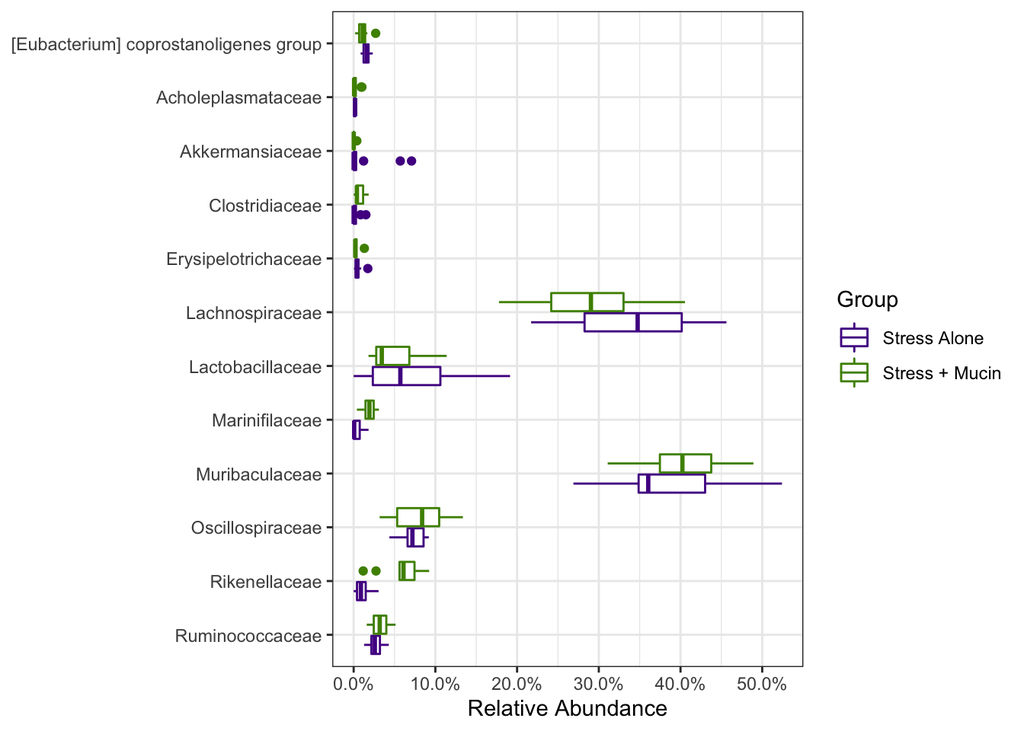

| Family | Unadjusted p value | Bonferroni-adjusted p value |
| --- | --- | --- |
| [Eubacterium] coprostanoligenes group | 0.0594980467103229 | 0.713976560523875 |
| Acholeplasmataceae | 0.525398682620381 | 1 |
| Akkermansiaceae | 0.610265044003458 | 1 |
| Clostridiaceae | 0.0121934639633766 | 0.146321567560519 |
| Erysipelotrichaceae | 0.235116613094807 | 1 |
| Lachnospiraceae | 0.0438791253167347 | 0.526549503800816 |
| Lactobacillaceae | 0.525398682620381 | 1 |
| Marinifilaceae | 0.000715352779862375 | 0.0085842333583485 |
| Muribaculaceae | 0.260447991905792 | 1 |
| Oscillospiraceae | 0.739898141971099 | 1 |
| Rikenellaceae | 0.000193616947595343 | 0.00232340337114412 |
| Ruminococcaceae | 0.287547020216289 | 1 |

The *Rikenellaceae* and *Marinifilaceae* families were significantly different between Stress Alone and Stress + Mucin groups after correction for multiple comparisons. *Clostridiaceae* and *Lachnospiraceae* were different before adjustment for multiple comparisons. Of note, *Lactobacillaceae* was not significantly different between groups, indicating that Mucin supplementation is acting in a *Lactobacillaceae*-independent manner.

### Selection of ASVs that Distinguish Between Groups

I’ve broadly looked at differences in diversity and community composition with the Mucin Supplementation experiment for the Gautier TUMI Pilot. I’ll now move on to identify ASVs that best discriminate between groups. There are two comparisons we are interested in for this experiment:

1. Baseline (n=24) vs. 3 Wk Stress samples (n=24)
2. Stress only (n=12) vs. Stress + Mucin (n=11)

ASVs will be selected by generating Random Forest models for each comparison. Models will be generated using training set data (a subset of the data containing 70% of samples), then model accuracy will be measured using test set data (the 30% of samples held out during model generation).

#### Baseline vs. 3 Week Stress Samples

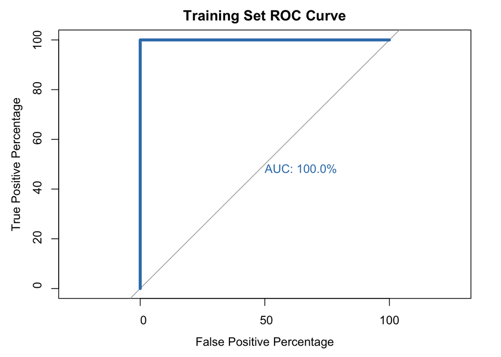

```
##
## Call:
## roc.default(response = outcome.stress.Train, predictor = model.rf.stress.final$votes[,     1], percent = TRUE, plot = TRUE, legacy.axes = TRUE, main = "Training Set ROC Curve",     xlab = "False Positive Percentage", ylab = "True Positive Percentage",     col = "#377eb8", lwd = 4, print.auc = TRU…
##
## Data: model.rf.stress.final$votes[, 1] in 16 controls (outcome.stress.Train Baseline) > 16 cases (outcome.stress.Train 3 Wk Stress).
## Area under the curve: 100%
```

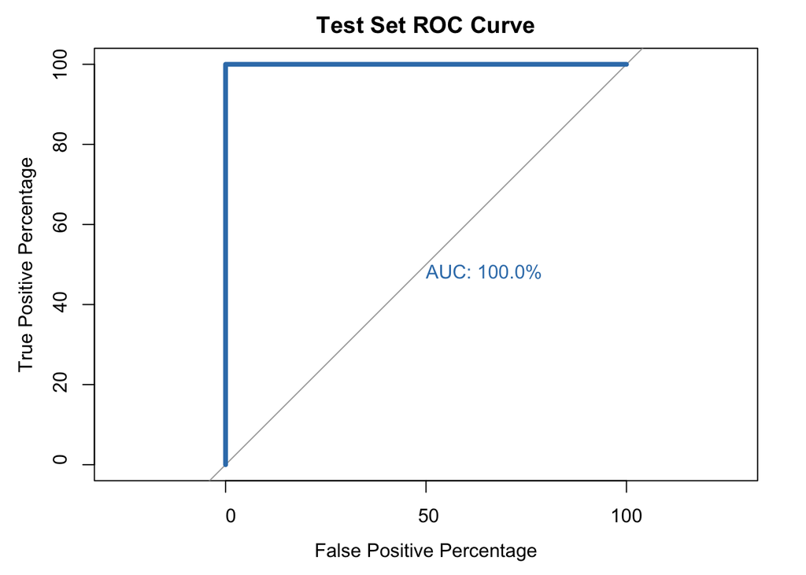

```
##
## Call:
## roc.default(response = outcome.stress.Test, predictor = pred.stress.data.frame$`3 Wk Stress`,     percent = TRUE, plot = TRUE, legacy.axes = TRUE, main = "Test Set ROC Curve",     xlab = "False Positive Percentage", ylab = "True Positive Percentage",     col = "#377eb8", lwd = 4, print.auc = TRUE…
##
## Data: pred.stress.data.frame$`3 Wk Stress` in 8 controls (outcome.stress.Test Baseline) < 8 cases (outcome.stress.Test 3 Wk Stress).
## Area under the curve: 100%
```

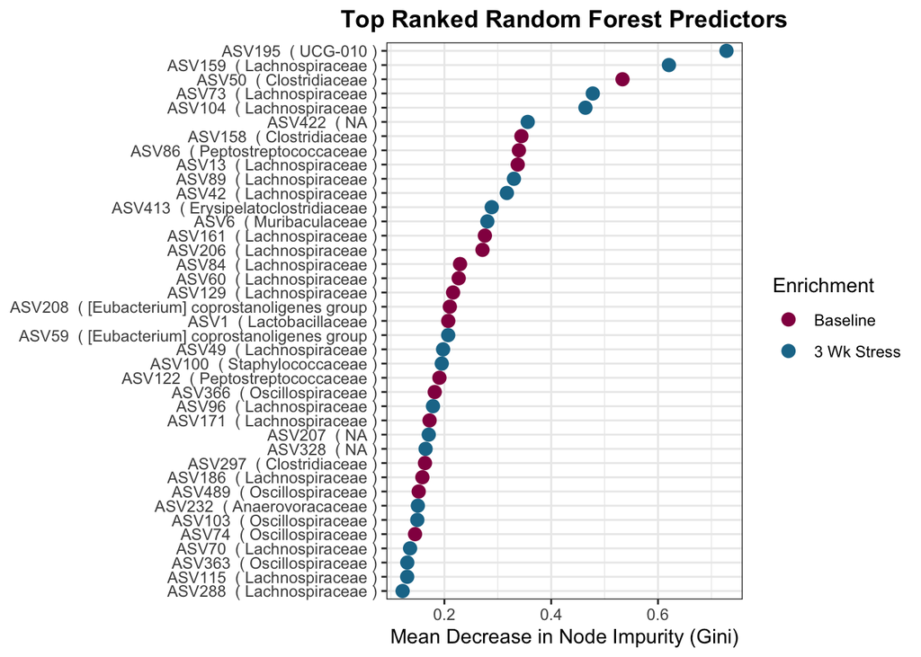

To confirm this, a separate random forest model was generated using only the top 5 ASVs selected by the original model. This new model was also able to correctly discriminate between Baseline and 3 Week Stress Groups (perfect on training set, 15/16 correct on test set), indicating that these ASVs are sufficient to discriminate between groups.

#### Stress Alone vs. Stress + Mucin

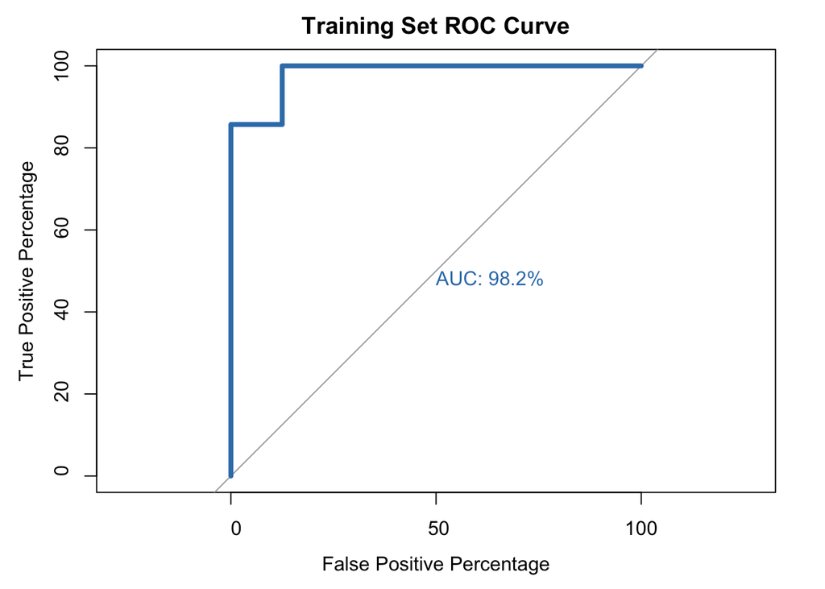

```
##
## Call:
## roc.default(response = outcome.mucin.Train, predictor = model.rf.mucin.final$votes[,     1], percent = TRUE, plot = TRUE, legacy.axes = TRUE, main = "Training Set ROC Curve",     xlab = "False Positive Percentage", ylab = "True Positive Percentage",     col = "#377eb8", lwd = 4, print.auc = TRUE)
##
## Data: model.rf.mucin.final$votes[, 1] in 8 controls (outcome.mucin.Train Stress Alone) > 7 cases (outcome.mucin.Train Stress + Mucin).
## Area under the curve: 98.21%
```

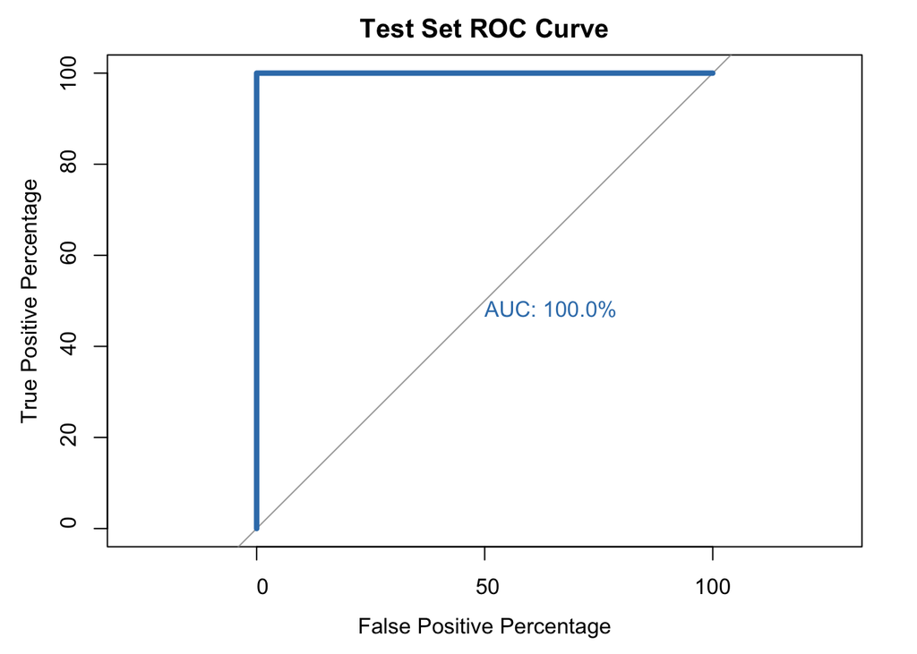

```
##
## Call:
## roc.default(response = outcome.mucin.Test, predictor = pred.mucin.data.frame$`Stress + Mucin`,     percent = TRUE, plot = TRUE, legacy.axes = TRUE, main = "Test Set ROC Curve",     xlab = "False Positive Percentage", ylab = "True Positive Percentage",     col = "#377eb8", lwd = 4, print.auc = TRU…
##
## Data: pred.mucin.data.frame$`Stress + Mucin` in 4 controls (outcome.mucin.Test Stress Alone) < 4 cases (outcome.mucin.Test Stress + Mucin).
## Area under the curve: 100%
```

This random forest model did not perform quite as well on the training set data compared to the Baseline vs. 3 Wk Stress. While this new model had a larger out-of-bag error rate compared to that model, it was able to correctly classify all samples in the test data set, indicating that it still performs well. The slightly impaired performance may reflect the smaller sample size for this comparison.

I’ll now look at the ASVs selected by this model.

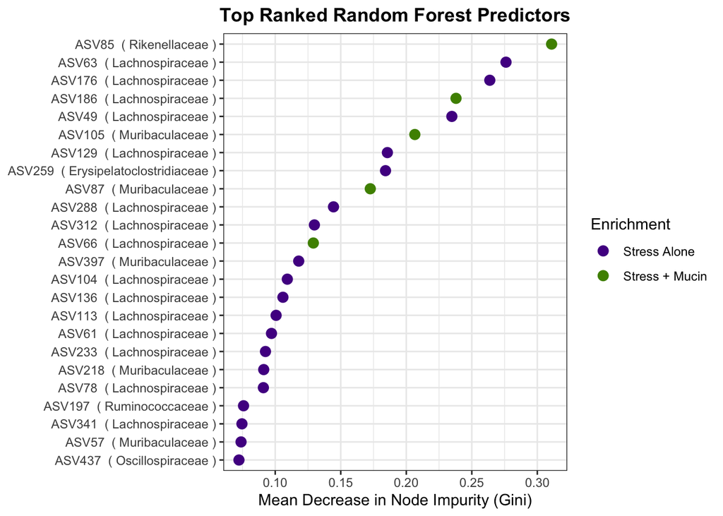

The ASVs that discriminate between Stress Alone and Stress + Mucin groups are once again dominated by *Lachnospiraceae* Family members. I’ll check to see how much overlap there is between the most important ASVs for the Baseline vs. 3 Wk Stress comparison and the Stress Alone vs. Stress + Mucin comparison.

| OTU | Stress.Mean.Decrease.Gini | Mucin.Mean.Decrease.Gini | Stress.RF.Rank | Mucin.RF.Rank | Enrichment.Stress | Enrichment.Mucin | Kingdom | Phylum | Class | Order | Family | Genus | ASV.Family |
| --- | --- | --- | --- | --- | --- | --- | --- | --- | --- | --- | --- | --- | --- |
| ASV159 | 0.6204478 | 0.0598786 | 2 | 30 | 3 Wk Stress | Stress Alone | Bacteria | Firmicutes | Clostridia | Lachnospirales | Lachnospiraceae | Lachnospiraceae UCG-001 | ASV159 ( Lachnospiraceae ) |
| ASV104 | 0.4641383 | 0.1092230 | 5 | 14 | 3 Wk Stress | Stress Alone | Bacteria | Firmicutes | Clostridia | Lachnospirales | Lachnospiraceae | NA | ASV104 ( Lachnospiraceae ) |
| ASV89 | 0.3302054 | 0.0366581 | 10 | 47 | 3 Wk Stress | Stress + Mucin | Bacteria | Firmicutes | Clostridia | Lachnospirales | Lachnospiraceae | Lachnospiraceae NK4A136 group | ASV89 ( Lachnospiraceae ) |
| ASV129 | 0.2163053 | 0.1855854 | 18 | 7 | Baseline | Stress Alone | Bacteria | Firmicutes | Clostridia | Lachnospirales | Lachnospiraceae | Lachnoclostridium | ASV129 ( Lachnospiraceae ) |
| ASV49 | 0.1975878 | 0.2347691 | 22 | 5 | 3 Wk Stress | Stress Alone | Bacteria | Firmicutes | Clostridia | Lachnospirales | Lachnospiraceae | Lachnospiraceae NK4A136 group | ASV49 ( Lachnospiraceae ) |
| ASV186 | 0.1587814 | 0.2379530 | 31 | 4 | Baseline | Stress + Mucin | Bacteria | Firmicutes | Clostridia | Lachnospirales | Lachnospiraceae | Tuzzerella | ASV186 ( Lachnospiraceae ) |
| ASV288 | 0.1217907 | 0.1444509 | 39 | 10 | 3 Wk Stress | Stress Alone | Bacteria | Firmicutes | Clostridia | Lachnospirales | Lachnospiraceae | GCA-900066575 | ASV288 ( Lachnospiraceae ) |

### Conclusions

This experiment focused on the role of stress and mucin supplementation on the diversity and community composition of the intestinal microbiota. Both stress and mucin supplementation significantly affected microbial beta diversity. Interestingly, changes in microbial evenness and beta diversity were strongest between 4 week samples and other timepoints, regardless of whether the samples were supplemented with mucin. This indicates that a mucin-independent feature (maybe diet) is driving this change.

Significant differences in the Family-level composition were observed between Baseline and 3 Week Stress samples, particularly in the *Lactobacillaceae* and *Muribaculaceae* Families. This difference in *Lactobacillaceae* is consistent with previous results from the lab. Random Forest modeling was able to clearly discriminate between Baseline and 3 Week Stress groups using the 16S data and identified several ASVs (mainly *Lachnospiraceae* and one *Lactobacillaceae*) which separate groups.

Signifcant differences were also observed at the Family level (*Marinifilaceae* and *Rikenellaceae*) with Stress Alone and Stress + Mucin groups. Some trends were observed with other Families, but they were not significant after correction with multiple comparisons. It’s worth noting that the sample size is smaller in this analysis than that for Baseline vs. 3 Week Stress. Random forest modeling also identified ASVs associated with Mucin supplementation, but most of these ASVs, including *Lactobacillaceae* were not the same ASVs identified in the Baseline vs. 3 Week Stress comparison. This suggests that mucin supplementation may be acting by a different mechanism than that identified by previous studies in the lab.